# Creel Data QAQC Report

Freshwater Recreational Fisheries Management Unit, WDFW

Author

Colt Holley

Published

March 13, 2024

This Quarto document is a tool for Washington Department of Fish and Wildlife (WDFW) staff within the Freshwater Recreational Fisheries Management (FRFM) work unit to perform quality assurance and quality control (QAQC) checks on angler catch and effort data obtained through creel surveys. It may be used in-season during the review of recently collected data or as a companion document to the fw_creel.Rmd analysis located at the CreelEstimates Github repository.

# Instructions

Review content of the tables and figures below to perform quality assurance checks on collected creel data. Look for outlier observations, deviations from study design, impossible or unexpected values, etc.

Many of the QAQC tables in this document contain a `creel_event_id` and/or `fishapps_event_link` field and corresponding values. These are provided to help users locate the specific data entry in the creel database. Upon reviewing the summaries in this document and identifying any necessary updates to the data entries, edits can be easily made in FishApps using the following instructions.

1. Log into [FishApps](https://apps.wdfw-fish.us/auth).
2. From this document, select either a `creel_event_id` or `fishapps_event_link` and copy to clipboard.
3. Paste onto browser tab with open FishApps session (method will be standardized).
   - If using whole link, paste the copied `fishapps_event_link`.
   - If using event_id, navigate to any event by using the “Search” feature in FishApps. Open an event and then paste over the `event_id` after “https://apps.wdfw-fish.us/creel/creel_event/” in the URL so that the event_id copied from the QAQC document creates a new link. Press enter to navigate to the event in question using the authenticated FishApps session.

## User-defined Parameters

| Parameters | Value |
| --- | --- |
| Fishery Name | Skagit winter steelhead 2024 |
| Fields where NA values are a concern | c("target_species", "trip_status", "boat_type", "fishing_end_time", "boat_used", "effort_start_time", "interview_time", "trailer_count") |

# Overview

## Missing values

This table summarizes the number of NA values within the creel data. Some columns have been hidden where many NA values are not unexpected or do not cause a potential error. The first panel in the tabset below shows the summary table and the second tab shows individual tables, where the first column is the variable of interest, to aid locating specific records in FishApps. There are three conditional variables, “boat_type”, “fish_from_boat”, and “fishing_end_time”, which will always produce tables if any rows are present, regardless of being in the `params$na_concerns` list. This is because of how they are calculated. Fish_from_boat may not be a concern for your specific creel project.

**Note**

Tables for additional fields of interest with NA values can be produced by entering the field name into the `na_concerns` list parameter at the beginning of the script and rendering again.

**Summary**

NA Summary Table

Skagit winter steelhead 2024

| Category | Column | NA Count | Percentage |
| --- | --- | --- | --- |
| interview | trip_guided | 4 | 1% |
|  | zip_code | 4 | 1% |
|  | previously_interviewed | 8 | 2% |
|  | fish_from_boat | 9 | 2% |
| catch | life_stage | 66 | 41% |
|  | fin_mark | 66 | 41% |
|  | fork_length_cm | 159 | 99% |
| effort | surveyor_num | 3688 | 99% |

**Tables**

| fish_from_boat | event_date | water_body | section_num | interview_number | creel_event_id |
| --- | --- | --- | --- | --- | --- |
| NA | 2024-02-25 | Skagit River | 1 | 4 | 6A81EAA6-36A3-4D2D-8F17-94360C41FA1B |
| NA | 2024-02-25 | Skagit River | 1 | 3 | 6A81EAA6-36A3-4D2D-8F17-94360C41FA1B |
| NA | 2024-03-03 | Skagit River | 1 | 1 | F3701AD5-6062-4FF4-A92F-4A828A7CF13A |
| NA | 2024-02-03 | Sauk River | 3 | 8 | 574E341D-05A2-45A5-BE3D-C71C5FFA0E2F |
| NA | 2024-02-07 | Sauk River | 3 | 10 | 90038405-24B0-4804-96A7-76642479380D |
| NA | 2024-02-28 | Sauk River | 3 | 2 | 82D43455-DA15-4277-AF15-DA9B7B8A4B88 |
| NA | 2024-03-06 | Sauk River | 3 | 3 | C193B2F8-6198-4B15-B5E7-F0752F094E2E |
| NA | 2024-03-06 | Sauk River | 3 | 5 | C193B2F8-6198-4B15-B5E7-F0752F094E2E |
| NA | 2024-02-18 | Skagit River | 2 | 3 | AF83CB44-E0FC-47D5-8F8C-D807C3E96A3D |

# Effort

## Census Counts

Table of recorded census effort count dates for the Skagit winter steelhead 2024 fishery. There have been 2 census effort count surveys to-date.

Census Effort Counts

| Survey Date | Section Number | Start Time | End Time | Duration |
| --- | --- | --- | --- | --- |
| 2024-02-17 | 3 | 12:56:00 | 13:16:00 | 20 min |
|  | 2 | 13:22:00 | 13:30:00 | 8 min |
|  | 1 | 13:32:00 | 13:42:00 | 10 min |
| 2024-03-05 | 3 | 13:43:00 | 13:58:00 | 15 min |
|  | 2 | 14:03:00 | 14:11:00 | 8 min |
|  | 1 | 14:11:00 | 14:21:00 | 10 min |

## Index Counts

Summary of index sites missing from effort count data

| Section number | Site name | Survey dates missed First | Survey dates missed Most recent | Survey dates missed Number |
| --- | --- | --- | --- | --- |
| 3 | Darrington Sauk-Prairie Road bridge (aka Darrington Mill Bridge) | 2024-02-03 | 2024-02-18 | 10 |

### Effort End Time < Start Time

```
There are no effort counts where end time < start time.
```

### Number of Index Sites Counted per Section

#### By section number and surveyor number

Vertical dashed lines indicate census effort count dates.

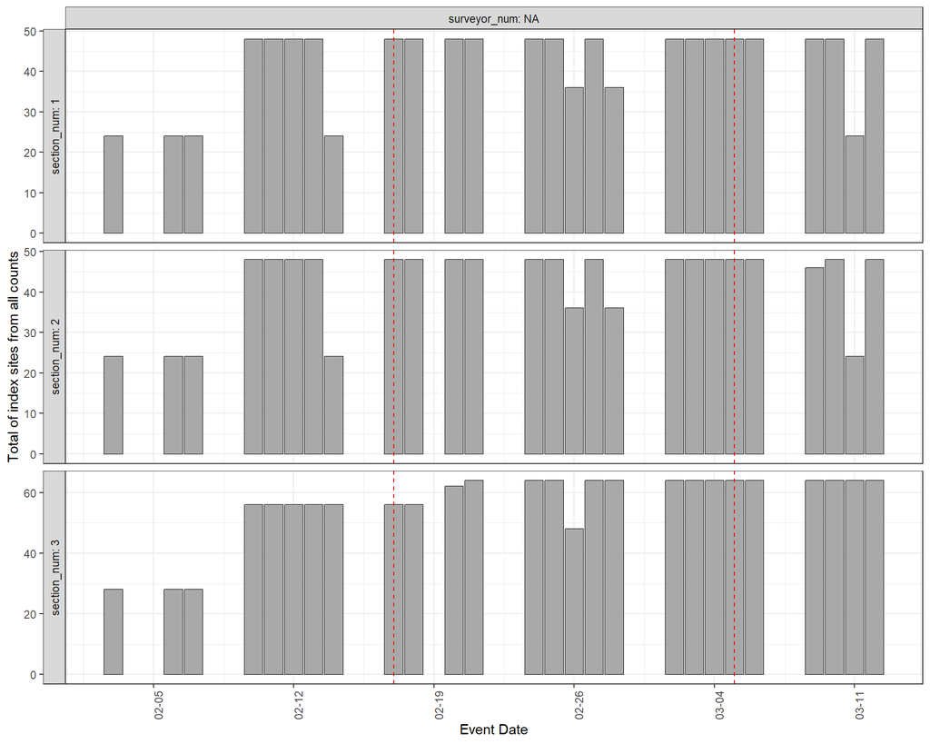

#### By section number and count sequence

Greatest number of recorded index effort counts within a day = **5** .

Histogram of index effort count sequence number.

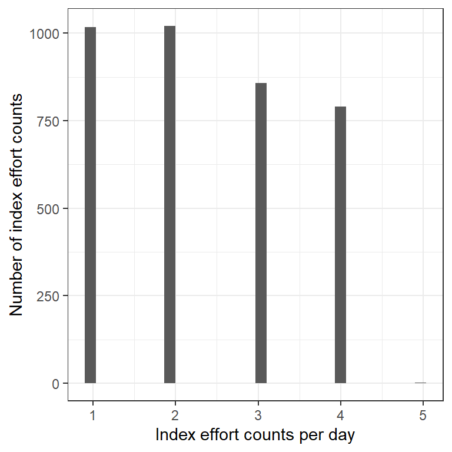

- How does this align with expected number of index counts from the study design?
- If there are unexpected count sequences, where in the data are they located?

Section and Sites Summary

Study design from fishery manager table

| Sections | Count of Index Sites |
| --- | --- |
| 1 | 6 |
| 2 | 6 |
| 3 | 8 |

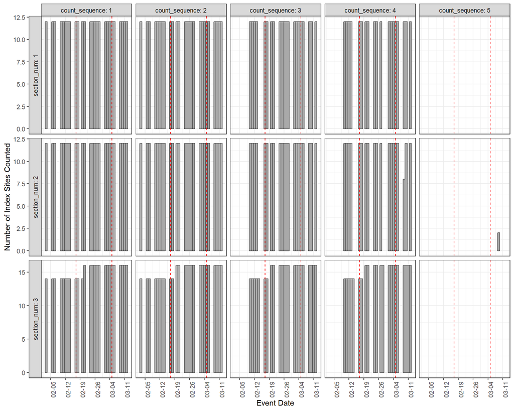

| count_sequence | event_date | water_body | project_name | fishery_name | fishapps_event_link |
| --- | --- | --- | --- | --- | --- |
| 5 | 2024-03-09 | Skagit River | District 14 | Skagit winter steelhead 2024 | https://apps.wdfw-fish.us/creel/creel_event/A79853E6-5921-4743-9033-3F4AE7F30728 |
| 5 | 2024-03-09 | Skagit River | District 14 | Skagit winter steelhead 2024 | https://apps.wdfw-fish.us/creel/creel_event/A79853E6-5921-4743-9033-3F4AE7F30728 |
| 4 | 2024-02-10 | Skagit River | District 14 | Skagit winter steelhead 2024 | https://apps.wdfw-fish.us/creel/creel_event/57C2EB68-7992-4103-BB06-B3D002768B9B |
| 4 | 2024-02-10 | Skagit River | District 14 | Skagit winter steelhead 2024 | https://apps.wdfw-fish.us/creel/creel_event/57C2EB68-7992-4103-BB06-B3D002768B9B |
| 4 | 2024-02-11 | Skagit River | District 14 | Skagit winter steelhead 2024 | https://apps.wdfw-fish.us/creel/creel_event/D4711FBB-B422-456F-816A-24C2542ADC64 |
| 4 | 2024-02-11 | Skagit River | District 14 | Skagit winter steelhead 2024 | https://apps.wdfw-fish.us/creel/creel_event/D4711FBB-B422-456F-816A-24C2542ADC64 |
| 4 | 2024-02-12 | Skagit River | District 14 | Skagit winter steelhead 2024 | https://apps.wdfw-fish.us/creel/creel_event/5B17EE7F-D965-4522-9C7D-F64D426D4FA5 |
| 4 | 2024-02-12 | Skagit River | District 14 | Skagit winter steelhead 2024 | https://apps.wdfw-fish.us/creel/creel_event/5B17EE7F-D965-4522-9C7D-F64D426D4FA5 |
| 4 | 2024-02-13 | Skagit River | District 14 | Skagit winter steelhead 2024 | https://apps.wdfw-fish.us/creel/creel_event/F65B7C96-59CD-4A41-9804-5B532DD26519 |
| 4 | 2024-02-13 | Skagit River | District 14 | Skagit winter steelhead 2024 | https://apps.wdfw-fish.us/creel/creel_event/F65B7C96-59CD-4A41-9804-5B532DD26519 |
| 4 | 2024-02-17 | Skagit River | District 14 | Skagit winter steelhead 2024 | https://apps.wdfw-fish.us/creel/creel_event/6BB97B2F-DBBD-45D5-B054-96717CD40386 |
| 4 | 2024-02-17 | Skagit River | District 14 | Skagit winter steelhead 2024 | https://apps.wdfw-fish.us/creel/creel_event/6BB97B2F-DBBD-45D5-B054-96717CD40386 |
| 4 | 2024-02-18 | Skagit River | District 14 | Skagit winter steelhead 2024 | https://apps.wdfw-fish.us/creel/creel_event/AF83CB44-E0FC-47D5-8F8C-D807C3E96A3D |
| 4 | 2024-02-18 | Skagit River | District 14 | Skagit winter steelhead 2024 | https://apps.wdfw-fish.us/creel/creel_event/AF83CB44-E0FC-47D5-8F8C-D807C3E96A3D |
| 4 | 2024-02-20 | Skagit River | District 14 | Skagit winter steelhead 2024 | https://apps.wdfw-fish.us/creel/creel_event/650B0410-D561-4B67-8FFC-C2F82C52A010 |
| 4 | 2024-02-20 | Skagit River | District 14 | Skagit winter steelhead 2024 | https://apps.wdfw-fish.us/creel/creel_event/650B0410-D561-4B67-8FFC-C2F82C52A010 |
| 4 | 2024-02-21 | Skagit River | District 14 | Skagit winter steelhead 2024 | https://apps.wdfw-fish.us/creel/creel_event/82716419-A48F-4607-A748-4D6AB4F844AE |
| 4 | 2024-02-21 | Skagit River | District 14 | Skagit winter steelhead 2024 | https://apps.wdfw-fish.us/creel/creel_event/82716419-A48F-4607-A748-4D6AB4F844AE |
| 4 | 2024-02-24 | Skagit River | District 14 | Skagit winter steelhead 2024 | https://apps.wdfw-fish.us/creel/creel_event/13094A71-A16D-4BAB-B28A-E920DC975207 |
| 4 | 2024-02-24 | Skagit River | District 14 | Skagit winter steelhead 2024 | https://apps.wdfw-fish.us/creel/creel_event/13094A71-A16D-4BAB-B28A-E920DC975207 |
| 4 | 2024-02-25 | Skagit River | District 14 | Skagit winter steelhead 2024 | https://apps.wdfw-fish.us/creel/creel_event/6A81EAA6-36A3-4D2D-8F17-94360C41FA1B |
| 4 | 2024-02-25 | Skagit River | District 14 | Skagit winter steelhead 2024 | https://apps.wdfw-fish.us/creel/creel_event/6A81EAA6-36A3-4D2D-8F17-94360C41FA1B |
| 4 | 2024-02-27 | Skagit River | District 14 | Skagit winter steelhead 2024 | https://apps.wdfw-fish.us/creel/creel_event/D7E693EF-8493-4BD4-BCC1-B5D03398D6F3 |
| 4 | 2024-02-27 | Skagit River | District 14 | Skagit winter steelhead 2024 | https://apps.wdfw-fish.us/creel/creel_event/D7E693EF-8493-4BD4-BCC1-B5D03398D6F3 |
| 4 | 2024-03-02 | Skagit River | District 14 | Skagit winter steelhead 2024 | https://apps.wdfw-fish.us/creel/creel_event/37C97452-C2D8-4F80-965A-142B0A2EA6EB |
| 4 | 2024-03-02 | Skagit River | District 14 | Skagit winter steelhead 2024 | https://apps.wdfw-fish.us/creel/creel_event/37C97452-C2D8-4F80-965A-142B0A2EA6EB |
| 4 | 2024-03-03 | Skagit River | District 14 | Skagit winter steelhead 2024 | https://apps.wdfw-fish.us/creel/creel_event/F3701AD5-6062-4FF4-A92F-4A828A7CF13A |
| 4 | 2024-03-03 | Skagit River | District 14 | Skagit winter steelhead 2024 | https://apps.wdfw-fish.us/creel/creel_event/F3701AD5-6062-4FF4-A92F-4A828A7CF13A |
| 4 | 2024-03-04 | Skagit River | District 14 | Skagit winter steelhead 2024 | https://apps.wdfw-fish.us/creel/creel_event/03F1ABBE-5BBC-4D0B-A124-EC3267147EFE |
| 4 | 2024-03-04 | Skagit River | District 14 | Skagit winter steelhead 2024 | https://apps.wdfw-fish.us/creel/creel_event/03F1ABBE-5BBC-4D0B-A124-EC3267147EFE |

[output cut: 3658 more lines]

# Interviews

Example histograms of numeric variables within interview data. In most cases we would expect discrete values for these variables (e.g., whole numbers - 3 anglers, 5th interview, 4 fishing poles). This is a chance to view potential outliers or unexpected patterns within the interview data.

**Histograms**

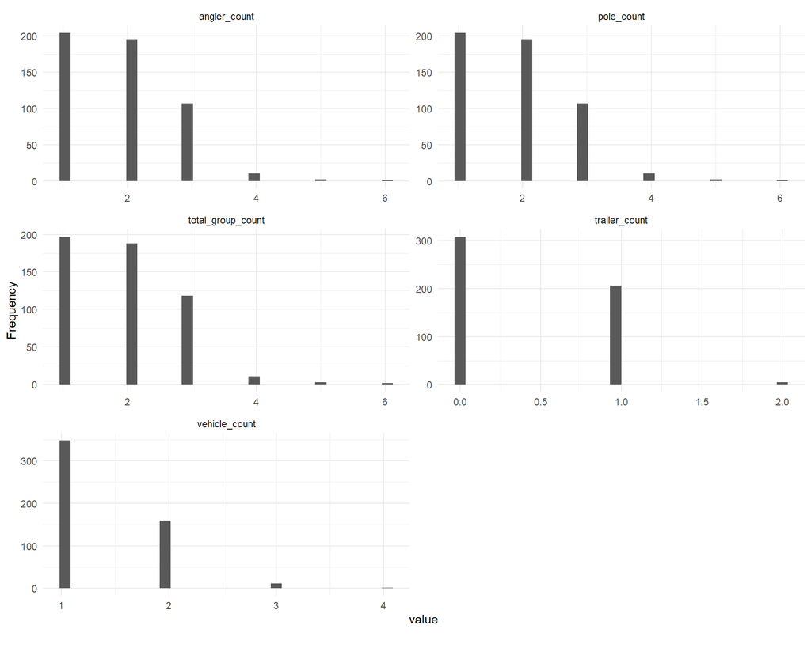

**Tables**

Angler Count

|  | angler_count | interview_number | fishapps_event_link |
| --- | --- | --- | --- |
| 1 | 6 | 7 | https://apps.wdfw-fish.us/creel/creel_event/574E341D-05A2-45A5-BE3D-C71C5FFA0E2F |
| 2 | 5 | 1 | https://apps.wdfw-fish.us/creel/creel_event/7A5A007F-E6CC-431B-8293-914C9845277C |
| 3 | 5 | 4 | https://apps.wdfw-fish.us/creel/creel_event/198312AF-E95E-439E-8C2E-4A444FF4AC2E |
| 4 | 4 | 3 | https://apps.wdfw-fish.us/creel/creel_event/57C2EB68-7992-4103-BB06-B3D002768B9B |
| 5 | 4 | 4 | https://apps.wdfw-fish.us/creel/creel_event/A79853E6-5921-4743-9033-3F4AE7F30728 |
| 6..518 |  |  |  |
| 519 | 1 | 1 | https://apps.wdfw-fish.us/creel/creel_event/DB74F7DA-9CC7-49F2-A577-1BCD196CEF8C |

Total Group Count

|  | total_group_count | interview_number | fishapps_event_link |
| --- | --- | --- | --- |
| 1 | 6 | 7 | https://apps.wdfw-fish.us/creel/creel_event/574E341D-05A2-45A5-BE3D-C71C5FFA0E2F |
| 2 | 6 | 9 | https://apps.wdfw-fish.us/creel/creel_event/935B66C8-7715-4608-96A2-BDE535249DEE |
| 3 | 5 | 1 | https://apps.wdfw-fish.us/creel/creel_event/7A5A007F-E6CC-431B-8293-914C9845277C |
| 4 | 5 | 4 | https://apps.wdfw-fish.us/creel/creel_event/198312AF-E95E-439E-8C2E-4A444FF4AC2E |
| 5 | 5 | 2 | https://apps.wdfw-fish.us/creel/creel_event/ADF7E4AA-6272-4EA8-97B8-8F65BFA8BE43 |
| 6..518 |  |  |  |
| 519 | 1 | 1 | https://apps.wdfw-fish.us/creel/creel_event/DB74F7DA-9CC7-49F2-A577-1BCD196CEF8C |

Pole Count

|  | pole_count | interview_number | fishapps_event_link |
| --- | --- | --- | --- |
| 1 | 6 | 7 | https://apps.wdfw-fish.us/creel/creel_event/574E341D-05A2-45A5-BE3D-C71C5FFA0E2F |
| 2 | 5 | 1 | https://apps.wdfw-fish.us/creel/creel_event/7A5A007F-E6CC-431B-8293-914C9845277C |
| 3 | 5 | 4 | https://apps.wdfw-fish.us/creel/creel_event/198312AF-E95E-439E-8C2E-4A444FF4AC2E |
| 4 | 4 | 3 | https://apps.wdfw-fish.us/creel/creel_event/57C2EB68-7992-4103-BB06-B3D002768B9B |
| 5 | 4 | 4 | https://apps.wdfw-fish.us/creel/creel_event/A79853E6-5921-4743-9033-3F4AE7F30728 |
| 6..518 |  |  |  |
| 519 | 1 | 1 | https://apps.wdfw-fish.us/creel/creel_event/DB74F7DA-9CC7-49F2-A577-1BCD196CEF8C |

Vehicle Count

|  | vehicle_count | interview_number | fishapps_event_link |
| --- | --- | --- | --- |
| 1 | 4 | 1 | https://apps.wdfw-fish.us/creel/creel_event/F72894D0-CE2E-4D49-9F2C-05A39299F278 |
| 2 | 3 | 7 | https://apps.wdfw-fish.us/creel/creel_event/D4711FBB-B422-456F-816A-24C2542ADC64 |
| 3 | 3 | 3 | https://apps.wdfw-fish.us/creel/creel_event/6A81EAA6-36A3-4D2D-8F17-94360C41FA1B |
| 4 | 3 | 6 | https://apps.wdfw-fish.us/creel/creel_event/B9F8D165-326F-4499-A98C-BD343A9AA96A |
| 5 | 3 | 2 | https://apps.wdfw-fish.us/creel/creel_event/8623488F-E843-4A1D-BF71-11EA5C7CBF7C |
| 6..518 |  |  |  |
| 519 | 1 | 1 | https://apps.wdfw-fish.us/creel/creel_event/DB74F7DA-9CC7-49F2-A577-1BCD196CEF8C |

Trailer Count

|  | trailer_count | interview_number | fishapps_event_link |
| --- | --- | --- | --- |
| 1 | 2 | 7 | https://apps.wdfw-fish.us/creel/creel_event/D4711FBB-B422-456F-816A-24C2542ADC64 |
| 2 | 2 | 9 | https://apps.wdfw-fish.us/creel/creel_event/935B66C8-7715-4608-96A2-BDE535249DEE |
| 3 | 2 | 2 | https://apps.wdfw-fish.us/creel/creel_event/82D43455-DA15-4277-AF15-DA9B7B8A4B88 |
| 4 | 2 | 1 | https://apps.wdfw-fish.us/creel/creel_event/5B7B4810-0420-4F40-9ABB-D2B107E2E045 |
| 5 | 2 | 3 | https://apps.wdfw-fish.us/creel/creel_event/AF83CB44-E0FC-47D5-8F8C-D807C3E96A3D |
| 6..518 |  |  |  |
| 519 | 0 | 1 | https://apps.wdfw-fish.us/creel/creel_event/DB74F7DA-9CC7-49F2-A577-1BCD196CEF8C |

## Incomplete Trip Status with Fishing End Time

Table of interviews with a recorded ‘fishing_end_time’ but have a ‘trip_status” as incomplete. All interviews with a ’fishing_end_time’ are assumed to be completed trips.

```
There are no interviews with a 'fishing_end_time' value and an Incomplete 'trip_status'
```

## Missing Trip Status

The table below contains interviews without a value for the column ‘trip_status’. All interviews are expected to either have ‘trip_status’ of either “Complete” or “Incomplete”.

```
There are no interviews with missing 'trip_status' values.
```

## Fishing End Time > Interview Time

```
There are no interviews where fishing end time > interview time.
```

## Fishing Start Time > Fishing End Time

```
There are no interviews where fishing start time > fishing end time.
```

## Trailer Count > Vehicle Count

```
There are no interviews where trailer count > vehicle count.
```

## Angler Count > Group Count

| QAQC_check | event_date | water_body | interview_number | angler_count | total_group_count | fishapps_event_link |
| --- | --- | --- | --- | --- | --- | --- |
| FAIL | 2024-03-09 | Skagit River | 1 | 3 | 2 | https://apps.wdfw-fish.us/creel/creel_event/A79853E6-5921-4743-9033-3F4AE7F30728 |

## Vehicle count > Group Count

```
There are no interviews where vehicle count > total group count.
```

# Catch

**Bar plots**

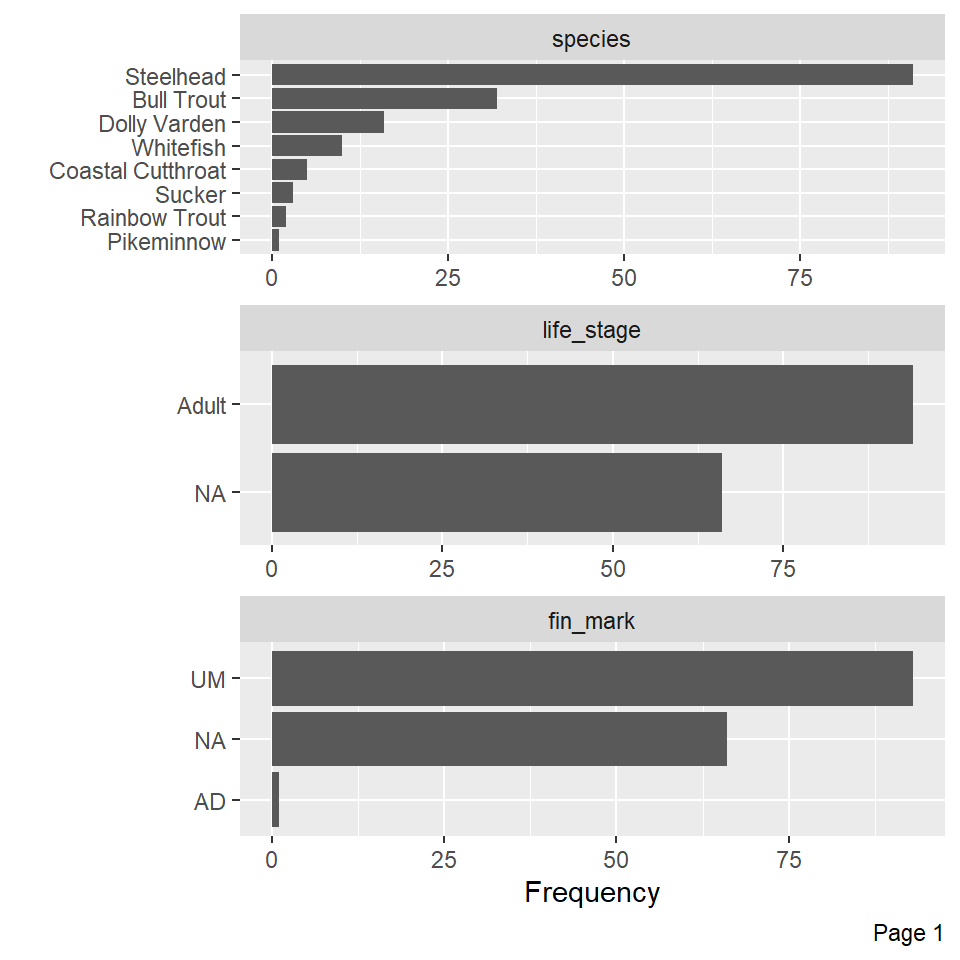

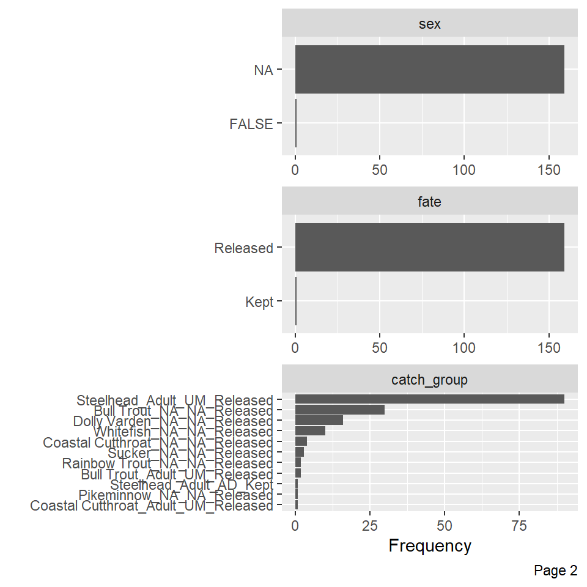

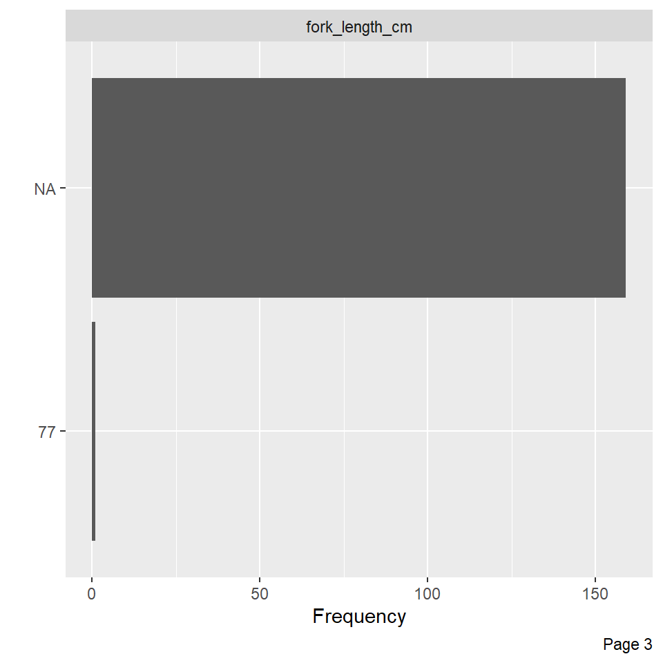

Bar plots of each column within the catch table, grouped by “**fin_mark**”. The horizontal axis represents a proportion.

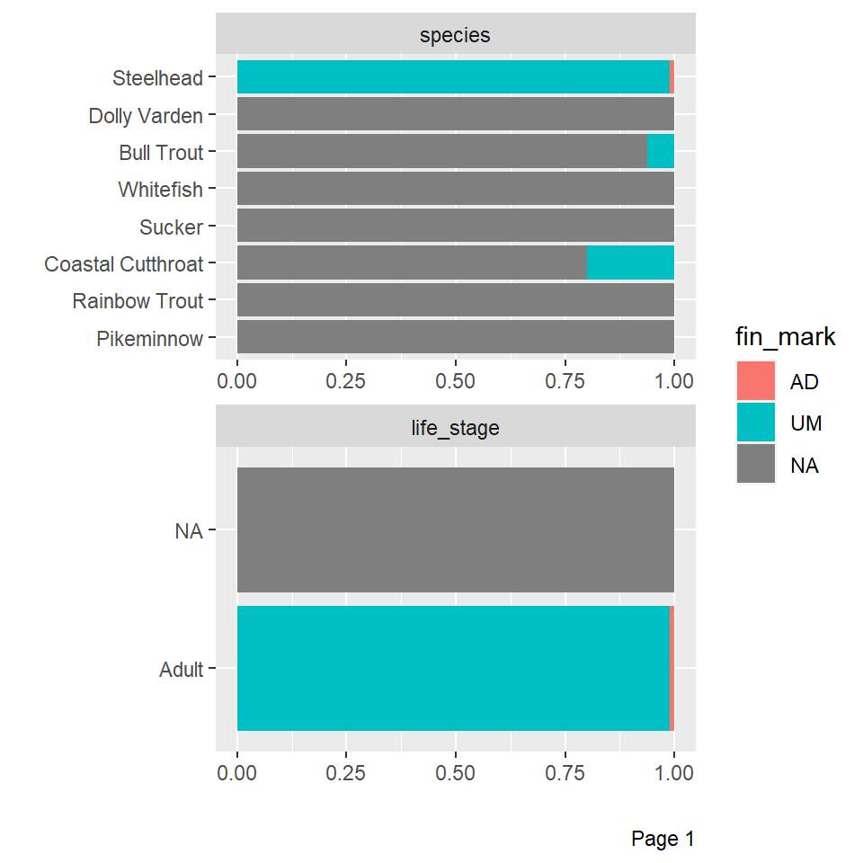

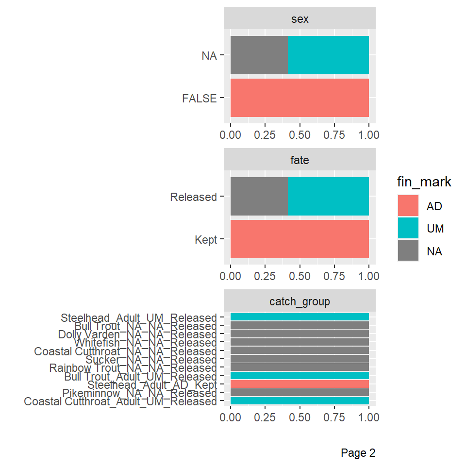

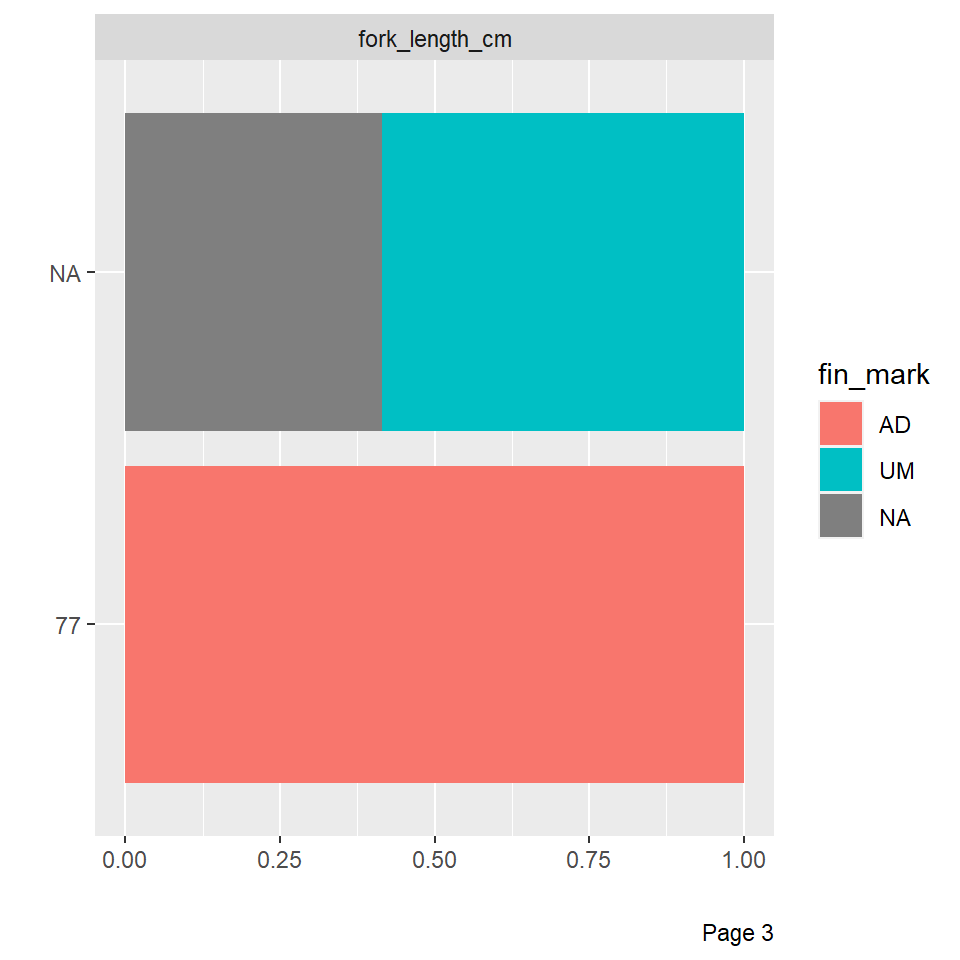

Bar plots of each column within the catch table, grouped by “**fate**”. The horizontal axis represents a proportion.

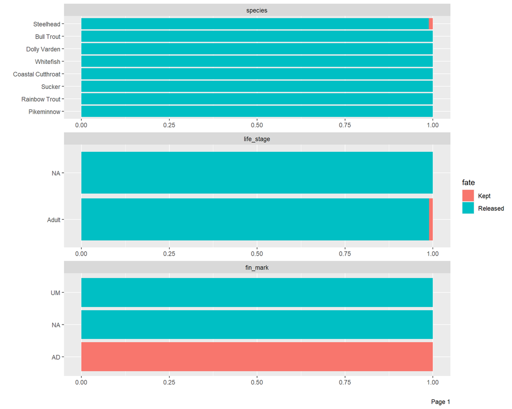

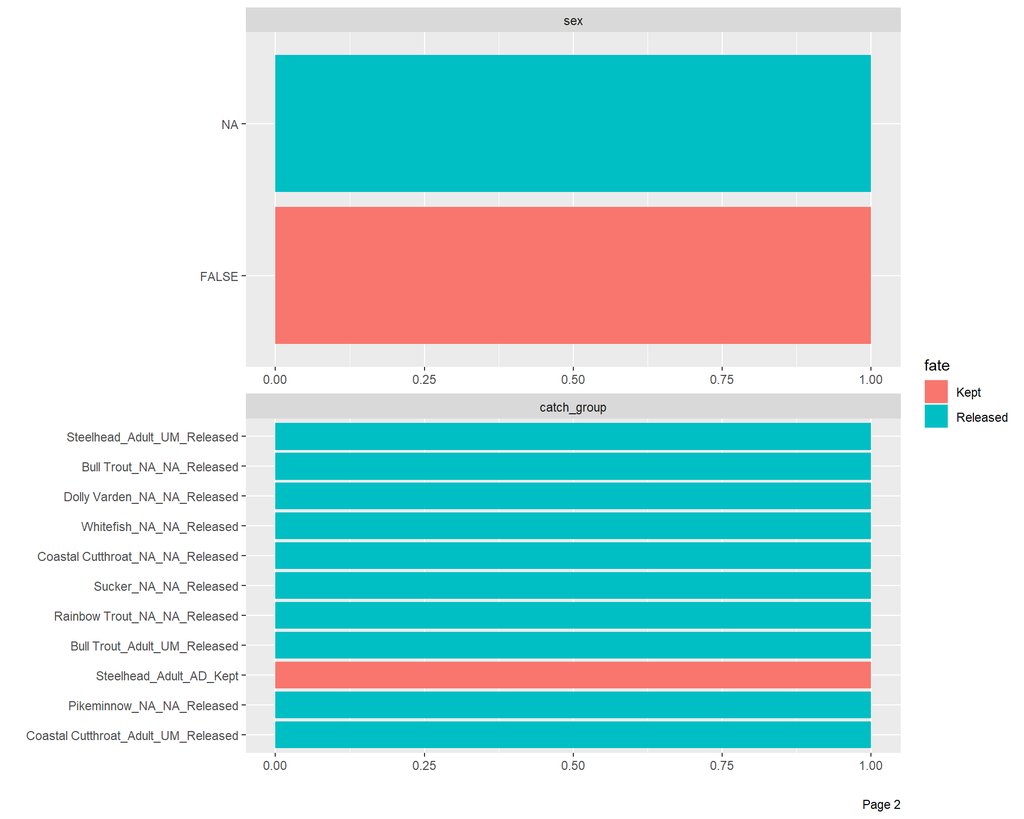

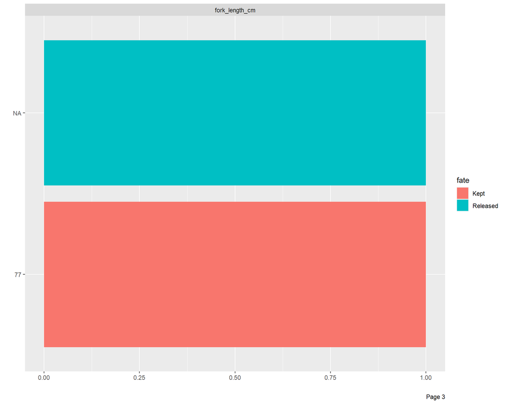

**Tables**

Look for categorical values that do not belong.

| species |
| --- |
| Whitefish |
| Bull Trout |
| Steelhead |
| Coastal Cutthroat |
| Pikeminnow |
| Dolly Varden |
| Rainbow Trout |
| Sucker |

| life_stage |
| --- |
| NA |
| Adult |

| fin_mark |
| --- |
| NA |
| UM |
| AD |

## Histogram of fish_count

Look for red values as potential outliers in number of fish reported in interviews.

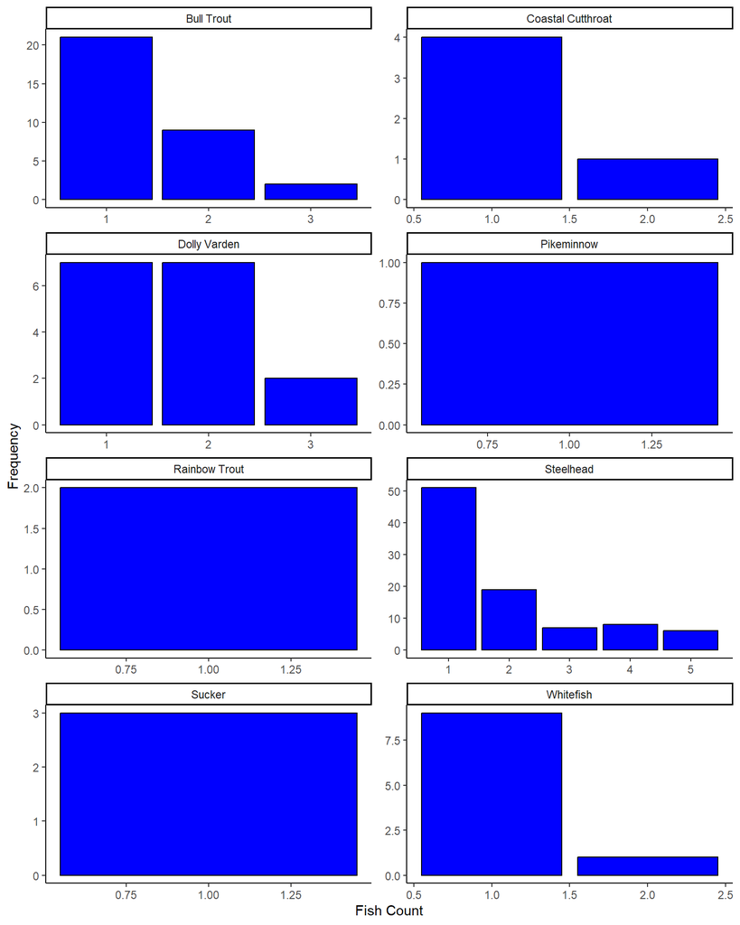

Table of fish_count, sorted from high to low.

[output not shown]